### Correlations between hemagglutination inhibition (HI) and viral neutralization (VN) titers and plasmablast and plasma B cells among trivalent inactivated influenza vaccine (TIV) vaccinees.

This reports reproduces Figure 2 of [Cao RG et al (2014)](http://www.jid.oxfordjournals.org/cgi/pmidlookup?view=long&pmid=24495909) published as part of the original study.

#### Load ImmuneSpaceR

```r
library(ImmuneSpaceR)
library(data.table)
library(ggplot2)
library(ggthemr)
```

#### Initialize the connection to SDY144 and get data

First we initialize the connection to the selected study using `CreateConnection`. Then we grab the datasets of interests with the `getDataset` method.

```r
con <- CreateConnection("SDY144")
flow <- con$getDataset("fcs_analyzed_result")
hai  <- con$getDataset("hai")
vn   <- con$getDataset("neut_ab_titer")
```

Then we select the cell populations and time points of intereset.

```r
pb <- flow[population_name_reported %in% c("Plasma cells,Freq. of,B lym CD27+",
                                           "Plasmablast,Freq. of,Q3: CD19+, CD20-")]
pb <- pb[, population_cell_number := as.numeric(population_cell_number)]
pb <- pb[study_time_collected == 7 & study_time_collected_unit == "Days"] #13 subjects
pb <- pb[, list(subject_accession, population_cell_number, population_name_reported)]
```

We compute the HI and VN titer as the fold-increase between baseline and day 30.

```r
# HAI
hai <- hai[,response:=value_reported/value_reported[study_time_collected==0],
                 by="virus_strain,arm_name,subject_accession"][study_time_collected==30]
hai <- hai[, list(subject_accession, virus_strain, response)]
dat_hai <- merge(hai, pb, by = "subject_accession", allow.cartesian = TRUE)
# VN
vn <- vn[, response:=value_reported/value_reported[study_time_collected==0],
                 by="virus_strain,arm_name,subject_accession"][study_time_collected==30]
vn <- vn[, list(subject_accession, virus_strain, response)]
dat_vn <- merge(vn, pb, by = "subject_accession", allow.cartesian = TRUE)
```

#### Plot using `ggplot2`

ImmuneSpace uses the *solarized* theme for plots.

```r
ggthemr('solarized')
```

Figure 2 A: Correlation between the absolute number of plasmablasts and plasma Bcells 7 days after vaccination with and fold-increase of HI titers from baseline to day 30 after vaccination.

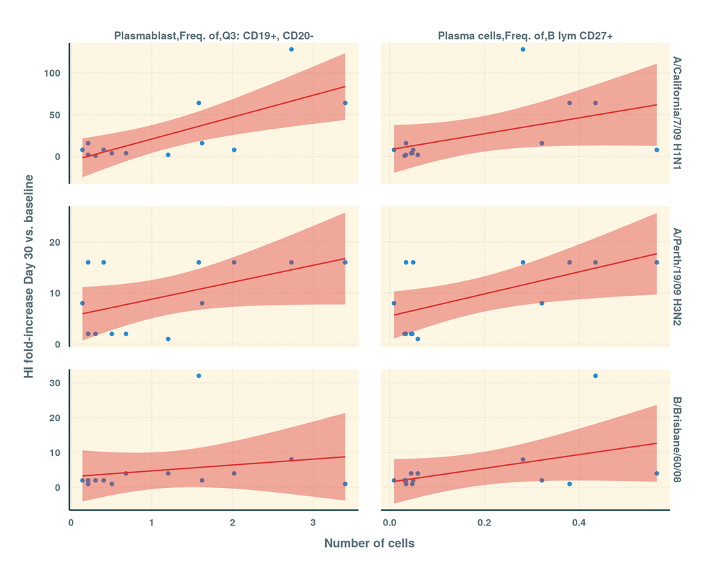

```r
ggplot(dat_hai, aes(x = population_cell_number, y = response)) +
  geom_point() + geom_smooth(method = "lm") +
  facet_grid(virus_strain~population_name_reported, scale = "free") +
  xlab("Number of cells") + ylab("HI fold-increase Day 30 vs. baseline")
```

Figure 2 B: Correlation between the absolute number of plasmablasts and plasma Bcells 7 days after vaccination with and fold-increase of VN titers from baseline to day 30 after vaccination.

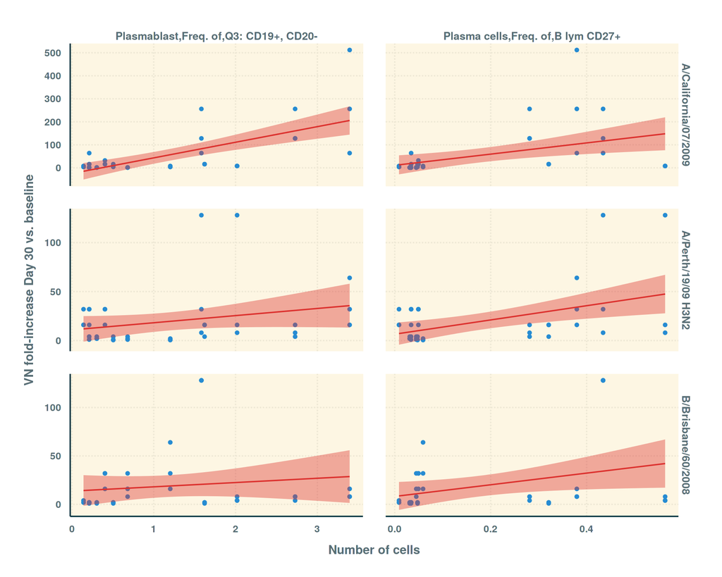

```r
ggplot(dat_vn, aes(x = population_cell_number, y = response)) +
  geom_point() + geom_smooth(method = "lm") +
  facet_grid(virus_strain~population_name_reported, scale = "free") +
  xlab("Number of cells") + ylab("VN fold-increase Day 30 vs. baseline")
```